# Predict Bike Sharing Demand with AutoGluon:

## Step 5: Rerun the model with the same settings as before, just with more features

```python
train_data = train.drop(["casual", "registered","datetime", "season", "weather"], axis=1).copy()
print(train_data.shape)
train_data.head(2)
```

```
(10886, 17)
```

|  | holiday | workingday | temp | atemp | humidity | windspeed | count | month | hour | season___1 | season___2 | season___3 | season___4 | weather___1 | weather___2 | weather___3 | weather___4 |
| --- | --- | --- | --- | --- | --- | --- | --- | --- | --- | --- | --- | --- | --- | --- | --- | --- | --- |
| 0 | 0 | 0 | 9.84 | 14.395 | 81 | 0.0 | 16 | 1 | 0 | 1 | 0 | 0 | 0 | 1 | 0 | 0 | 0 |
| 1 | 0 | 0 | 9.02 | 13.635 | 80 | 0.0 | 40 | 1 | 1 | 1 | 0 | 0 | 0 | 1 | 0 | 0 | 0 |

```python
predictor_new_features = TabularPredictor(label = "count",
                                          eval_metric = "root_mean_squared_error").fit(train_data = train_data,
                                                                                       presets = "best_quality",
                                                                                       time_limit = 600)
```

[output not shown]

[output cut: 88 more lines]

```
Fitting model: NeuralNetTorch_BAG_L2 ... Training model for up to 17.31s of the 17.3s of remaining time.
	Fitting 8 child models (S1F1 - S1F8) | Fitting with ParallelLocalFoldFittingStrategy
	Time limit exceeded... Skipping NeuralNetTorch_BAG_L2.
Fitting model: LightGBMLarge_BAG_L2 ... Training model for up to 12.56s of the 12.55s of remaining time.
	Fitting 8 child models (S1F1 - S1F8) | Fitting with ParallelLocalFoldFittingStrategy
	-60.7906	 = Validation score   (root_mean_squared_error)
	18.8s	 = Training   runtime
	0.22s	 = Validation runtime
Completed 1/20 k-fold bagging repeats ...
Fitting model: WeightedEnsemble_L3 ... Training model for up to 360.0s of the -10.36s of remaining time.
	-59.0583	 = Validation score   (root_mean_squared_error)
	0.5s	 = Training   runtime
	0.0s	 = Validation runtime
AutoGluon training complete, total runtime = 610.9s ... Best model: "WeightedEnsemble_L3"
TabularPredictor saved. To load, use: predictor = TabularPredictor.load("AutogluonModels/ag-20220504_124908/")
```

```python
predictor_new_features.fit_summary()
```

```
*** Summary of fit() ***
Estimated performance of each model:
                     model   score_val  pred_time_val    fit_time  pred_time_val_marginal  fit_time_marginal  stack_level  can_infer  fit_order
0      WeightedEnsemble_L3  -59.058300      12.007252  513.350124                0.000728           0.500124            3       True         20
1          CatBoost_BAG_L2  -59.504854      10.807802  407.585760                0.082533          26.065669            2       True         15
2      WeightedEnsemble_L2  -59.848040       9.467155  320.721324                0.000666           0.653182            2       True         11
3     ExtraTreesMSE_BAG_L2  -59.873511      11.283589  387.764375                0.558319           6.244285            2       True         16
4           XGBoost_BAG_L2  -59.962004      10.825272  399.258880                0.100002          17.738789            2       True         18
5   NeuralNetFastAI_BAG_L2  -60.052204      11.046964  444.002763                0.321694          62.482672            2       True         17
6          LightGBM_BAG_L2  -60.288147      10.795891  395.373542                0.070621          13.853451            2       True         13
7   RandomForestMSE_BAG_L2  -60.412030      11.287804  404.302627                0.562534          22.782537            2       True         14
8     LightGBMLarge_BAG_L2  -60.790624      10.943976  400.318586                0.218706          18.798495            2       True         19
9          CatBoost_BAG_L1  -60.902060       0.118614  175.921464                0.118614         175.921464            1       True          6
10       LightGBMXT_BAG_L2  -60.909952      10.962675  396.761416                0.237405          15.241326            2       True         12
11         LightGBM_BAG_L1  -61.703091       1.760851   23.157769                1.760851          23.157769            1       True          4
12       LightGBMXT_BAG_L1  -61.745770       6.819043   52.483192                6.819043          52.483192            1       True          3
13          XGBoost_BAG_L1  -63.048889       0.395736   18.443300                0.395736          18.443300            1       True          9
14    ExtraTreesMSE_BAG_L1  -66.224989       0.495928    3.440316                0.495928           3.440316            1       True          7
15  RandomForestMSE_BAG_L1  -66.976749       0.497535    6.148289                0.497535           6.148289            1       True          5
16  NeuralNetFastAI_BAG_L1  -69.973191       0.270444   62.357428                0.270444          62.357428            1       True          8
17   NeuralNetTorch_BAG_L1  -84.122803       0.160426   39.519461                0.160426          39.519461            1       True         10
18   KNeighborsDist_BAG_L1 -120.231459       0.103750    0.024160                0.103750           0.024160            1       True          2
19   KNeighborsUnif_BAG_L1 -122.017317       0.102942    0.024711                0.102942           0.024711            1       True          1
Number of models trained: 20
Types of models trained:
{'StackerEnsembleModel_NNFastAiTabular', 'StackerEnsembleModel_XT', 'StackerEnsembleModel_RF', 'WeightedEnsembleModel', 'StackerEnsembleModel_XGBoost', 'StackerEnsembleModel_CatBoost', 'StackerEnsembleModel_KNN', 'StackerEnsembleModel_TabularNeuralNetTorch', 'StackerEnsembleModel_LGB'}
Bagging used: True  (with 8 folds)
Multi-layer stack-ensembling used: True  (with 3 levels)
Feature Metadata (Processed):
(raw dtype, special dtypes):
('float', [])     :  3 | ['temp', 'atemp', 'windspeed']
('int', [])       :  3 | ['humidity', 'month', 'hour']
('int', ['bool']) : 10 | ['holiday', 'workingday', 'season___1', 'season___2', 'season___3', ...]
Plot summary of models saved to file: AutogluonModels/ag-20220504_124908/SummaryOfModels.html
*** End of fit() summary ***
```

[output not shown]

[output cut: 199 more lines]

```
 5          17
 6          13
 7          14
 8          19
 9           6
 10         12
 11          4
 12          3
 13          9
 14          7
 15          5
 16          8
 17         10
 18          2
 19          1  }
```

```python
predictions = predictor_new_features.predict(test.drop(["datetime", "season", "weather"], axis=1))
predictions.head()
```

```
0    20.487020
1     7.517329
2     5.566364
3     4.518532
4     4.737297
Name: count, dtype: float32
```

```python
# Remember to set all negative values to zero
print(len(predictions[predictions < 0]))
# Set them to zero
predictions[predictions < 0] = 0
print(len(predictions[predictions < 0]))
```

```
1
0
```

```python
# Same submitting predictions
submission_new_features = submission.copy()
submission_new_features["count"] = predictions
submission_new_features.to_csv("submission_new_features.csv", index=False)
```

```python
# !kaggle competitions submit -c bike-sharing-demand -f submission_new_features.csv -m "new features"
```

```python
# !kaggle competitions submissions -c bike-sharing-demand | tail -n +1 | head -n 6
```

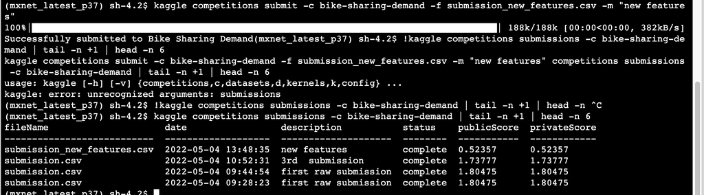

- publicScore: 0.52357
- privateScore: 0.52357

## Step 6: Hyper parameter optimization

- There are many options for hyper parameter optimization.
- Options are to change the AutoGluon higher level parameters or the individual model hyperparameters.
- The hyperparameters of the models themselves that are in AutoGluon. Those need the `hyperparameter` and `hyperparameter_tune_kwargs` arguments.

```python
time_limit = 20*60
nn_options = {
    'num_epochs': 20,
    'learning_rate': ag.space.Real(1e-4, 1e-2, default=5e-4, log=True),  # learning rate used in training (real-valued hyperparameter searched on log-scale)
    'activation': ag.space.Categorical('relu', 'softrelu', 'tanh'),  # activation function used in NN (categorical hyperparameter, default = first entry)
    'layers': ag.space.Categorical([100], [1000], [200, 100], [300, 200, 100]),  # each choice for categorical hyperparameter 'layers' corresponds to list of sizes for each NN layer to use
    'dropout_prob': ag.space.Real(0.0, 0.5, default=0.1),  # dropout probability (real-valued hyperparameter)
}

gbm_options = {  # specifies non-default hyperparameter values for lightGBM gradient boosted trees
    'num_boost_round': 200,  # number of boosting rounds (controls training time of GBM models)
    'num_leaves': ag.space.Int(lower=26, upper=66, default=36),  # number of leaves in trees (integer hyperparameter)
}

search_strategy = 'auto'  # to tune hyperparameters using Bayesian optimization routine with a local scheduler

hyperparameter_tune_kwargs = {  # HPO is not performed unless hyperparameter_tune_kwargs is specified
    'scheduler' : 'local',
    'searcher': search_strategy,
}

predictor_new_hpo2 = TabularPredictor(label='count', eval_metric='root_mean_squared_error').fit(train_data,
                                                                                                presets='best_quality',
                                                                                                time_limit=time_limit,
                                                                                                hyperparameters={'NN': nn_options, 'GBM': gbm_options},
                                                                                                hyperparameter_tune_kwargs=hyperparameter_tune_kwargs)
```

[output not shown]

[output cut: 693 more lines]

```
	-62.298	 = Validation score   (root_mean_squared_error)
	67.27s	 = Training   runtime
	1.14s	 = Validation runtime
Fitting model: NeuralNetMXNet_BAG_L2/T2 ... Training model for up to 60.28s of the 60.25s of remaining time.
	Fitting 7 child models (S1F2 - S1F8) | Fitting with ParallelLocalFoldFittingStrategy
	-66.7243	 = Validation score   (root_mean_squared_error)
	62.57s	 = Training   runtime
	1.67s	 = Validation runtime
Completed 1/20 k-fold bagging repeats ...
Fitting model: WeightedEnsemble_L3 ... Training model for up to 360.0s of the 4.15s of remaining time.
	-61.0905	 = Validation score   (root_mean_squared_error)
	0.43s	 = Training   runtime
	0.0s	 = Validation runtime
AutoGluon training complete, total runtime = 1196.31s ... Best model: "WeightedEnsemble_L3"
TabularPredictor saved. To load, use: predictor = TabularPredictor.load("AutogluonModels/ag-20220504_135529/")
```

```python
predictor_new_hpo2.fit_summary()
```

```
*** Summary of fit() ***
Estimated performance of each model:
                       model   score_val  pred_time_val    fit_time  pred_time_val_marginal  fit_time_marginal  stack_level  can_infer  fit_order
0        LightGBM_BAG_L1/T65  -59.659683       0.024017    0.494394                0.024017           0.494394            1       True         65
1        LightGBM_BAG_L1/T70  -60.902415       0.020076    0.432168                0.020076           0.432168            1       True         70
2        WeightedEnsemble_L3  -61.090523      16.139816  798.258018                0.000679           0.434283            3       True         89
3        LightGBM_BAG_L1/T63  -61.206132       0.024544    0.513475                0.024544           0.513475            1       True         63
4        LightGBM_BAG_L1/T55  -61.381648       0.022366    0.483956                0.022366           0.483956            1       True         55
5        WeightedEnsemble_L2  -61.608730       1.360449   61.313748                0.000758           0.355582            2       True         75
6         LightGBM_BAG_L2/T7  -61.720029      13.214344  633.371009                0.059933          16.231253            2       True         82
7         LightGBM_BAG_L2/T2  -61.814379      13.230971  633.923878                0.076561          16.784122            2       True         77
8         LightGBM_BAG_L2/T1  -62.024440      13.248036  636.440844                0.093625          19.301089            2       True         76
9         LightGBM_BAG_L2/T5  -62.098918      13.275709  637.347919                0.121299          20.208163            2       True         80
10       LightGBM_BAG_L2/T10  -62.118424      13.199295  634.973340                0.044885          17.833584            2       True         85
11       LightGBM_BAG_L1/T66  -62.203187       0.019027    0.402277                0.019027           0.402277            1       True         66
```

[output cut: 89 more lines]

[output not shown]

[output cut: 789 more lines]

```

     fit_order
 0          65
 1          70
 2          89
 3          63
 4          55
 ..        ...
 84          4
 85         53
 86         73
 87         12
 88         29

 [89 rows x 9 columns]}
```

```python
predictions = predictor_new_hpo2.predict(test.drop(["datetime", "season", "weather"], axis=1))

# Remember to set all negative values to zero
print(len(predictions[predictions < 0]))
# Set them to zero
predictions[predictions < 0] = 0
print(len(predictions[predictions < 0]))
```

```
0
0
```

```python
# Same submitting predictions
submission_new_features = submission.copy()
submission_new_features["count"] = predictions
submission_new_features.to_csv("submission_new_hpo2.csv", index=False)
```

```python
# !kaggle competitions submit -c bike-sharing-demand -f submission_new_hpo2.csv -m "new features with hyperparameters"
# !kaggle competitions submissions -c bike-sharing-demand | tail -n +1 | head -n 6
```

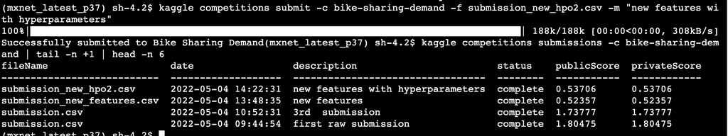

- publicScore: 0.53706
- privateScore: 0.53706

## Step 7: Write a Report

### Refer to the markdown file for the full report

### Creating plots and table for report

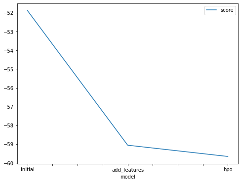

```python
# Taking the top model score from each training run and creating a line plot to show improvement
# You can create these in the notebook and save them to PNG or use some other tool (e.g. google sheets, excel)
fig = pd.DataFrame(
    {
        "model": ["initial", "add_features", "hpo"],
        "score": [-51.884555 , -59.058300, -59.659683  ]
    }
).plot(x="model", y="score", figsize=(8, 6)).get_figure()
fig.savefig('model_train_score.png')
```

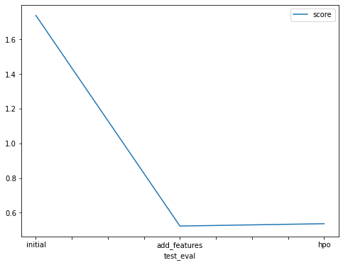

```python
# Take the 3 kaggle scores and creating a line plot to show improvement
fig = pd.DataFrame(
    {
        "test_eval": ["initial", "add_features", "hpo"],
        "score": [1.73777, 0.52357, 0.53706]
    }
).plot(x="test_eval", y="score", figsize=(8, 6)).get_figure()
fig.savefig('model_test_score.png')
```

### Hyperparameter table

```python
pd.DataFrame({
    "model": ["initial", "add_features", "hpo"],
    "num_epochs": ['default', 'default', 20],
    "num_boost_round": ['default', 'default', 200],
    "time": [600, 600, 1200],
    "score":  [-51.884555 , -59.058300, -59.659683  ]
})
```

|  | model | num_epochs | num_boost_round | time | score |
| --- | --- | --- | --- | --- | --- |
| 0 | initial | default | default | 600 | -51.884555 |
| 1 | add_features | default | default | 600 | -59.058300 |
| 2 | hpo | 20 | 200 | 1200 | -59.659683 |